# 롯데백화점 남/녀 예측분석

롯데백화점 데이터로 남/녀를 구분하는 분류분석을 시행하려 한다. 현 데이터는 남성보다 여성이 더 많은 불균형 데이터이다. 따라서 성별에 따른 특징이 보이는 피쳐를 생성하고자 노력하였다. 피쳐는 크게 5가지 관점(가격, 시간, 장소, 제품, 기타)으로 고객을 파악 및 구분하고자 하였다. 또한 2차적으로 제품을 좀더 구체적으로 분석하여 남성 또는 여성에 확실히 치우친 물품들의 구매여부를 추가하였다. 이러한 피쳐들의 유용성을 판단하기 위해서 countplot과 kdeplot을 통한 탐색적 데이터분석을 진행하였다. EDA이후 상관관계가 높은 피쳐들을 확인하였고 이를 일부 제거하여 모든 피쳐끼리 상관관계가 0.7를 넘지 않음을 확인하였다. 이후 전처리에서 스케일링을 위해서 먼저 이상치를 일부 제거하였으며 차례대로 로그변환과 MinMaxScaling 그리고 PCA와 Select Features 과정을 거쳤다. 이러한 전처리를 거쳐서 1400개의 피쳐에서 최종적으로 41개의 피쳐를 채택하였다. 모델링에는 데이터불균형을 해소시키기 위해서 모든 모델에 기본적으로 Stratified KFold을 적용하였다. 튜닝은 베이지안 최적화를 이용하여 모델마다 가장 최적화된 파라미터를 찾고자 하였으며 훈련데이터를 모두 활용하고자 train_test_split없이 cross_val_score를 이용하였다. 이렇게 튜닝된 모델들로 먼저 S_train, S_test transform을 진행하고 이후 최적 모델이었던 4가지 모델을 메타모델로 지정 및 베이지안 최적화를 거친후 스태킹을 진행하였다. 이렇게 4개의 스태킹 결과를 내었고 이후 추가적으로 3층 스태킹을 메타모델들을 이용하여 간단히 산술평균으로 결과를 내었다. 추가적으로 해볼 수 있는 부분들이 아직 많은데 그중에서 스태킹 이후 메타모델을 교차검정을 통하였을때 더욱 점수가 향상되는지가 살펴봐야할 부분이다

### process

#### ch.1 Libraries, Read data, Simple Preprocessing

#### ch.2 Features

```
  (1차 생성 features)    -> 1200 여개
- 1. 가격
- 2. 시간
- 3. 장소
- 4. 제품
- 5. 기타

+ (2차 생성 features)    -> 200 여개 [- 추가된 부분 -]
- 남성경향물품 구매여부
- 여성경향물품 구매여부

- 피쳐 상관관계 0.7이상 제거
- 피쳐 전처리
  - 이상치 제거
  - 로그변환
  - MinMaxScaling
  - PCA
  - Select Features   -> 최종피쳐 : 41개
```

#### ch.3 modeling

```
- Basic models with Skf -> LogReg 새로추가
- Tuning with BaysianOptimization
```

#### ch.4 Ensemble

```
- Stacking: meta_model1: LGBM with BO
          : meta_model2: LogReg with BO
          : meta_model3: XGB with BO
          : meta_model4: EXTRA with BO

- 3 layer stacking
    level-1 : LR, RF, EXTRA, GBM, XGB, LGBM -> S_train, S_text
    level-2 : meta_LR, meta_EXTRA, meta_XGB, meta_LGBM
    level-3 : Soft Voting
```

#### 비교해볼수 있었던 점:

```
- before preprocessing vs after preprocessing
- 1200 features(1st assignment) vs 41 features(2nd assignment)
- meta_model with BO vs 3-layer stacking Soft-Voting
```

#### 추가로 해볼 수 있는 점:

```
  - voting_model이나 stacking의 meta_model로 교차검정 앙상블
  - 3층 스태킹으로 교차검정
  - 3층 스태킹으로 기하평균, 멱평균
```

## ch.1 Libraries, Read data, Simple Preprocessing

### Libraries

```python
# basic

import pandas as pd
import numpy as np
import warnings
warnings.filterwarnings('ignore')
pd.set_option('display.max_columns', 50, 'display.max_rows', 200)


# plot

import seaborn as sns
import matplotlib.pylab as plt
from matplotlib import font_manager, rc
%matplotlib inline

import platform
your_os = platform.system()
if your_os == 'Linux':
    rc('font', family='NanumGothic')
elif your_os == 'Windows':
    ttf = "c:/Windows/Fonts/malgun.ttf"
    font_name = font_manager.FontProperties(fname=ttf).get_name()
    rc('font', family=font_name)
elif your_os == 'Darwin':
    rc('font', family='AppleGothic')
rc('axes', unicode_minus=False)


# models
import time
from tqdm import tqdm
from sklearn.model_selection import train_test_split
from sklearn.model_selection import cross_val_score
from sklearn.metrics import roc_auc_score
from sklearn.model_selection import StratifiedKFold, KFold

from sklearn.ensemble import RandomForestClassifier
from sklearn.neighbors import KNeighborsClassifier
from sklearn.linear_model import LogisticRegression
from sklearn.svm import SVC
from sklearn.ensemble import GradientBoostingClassifier
from lightgbm import LGBMClassifier
from xgboost import XGBClassifier
from sklearn.neural_network import MLPClassifier
from sklearn.ensemble import ExtraTreesClassifier

from sklearn.model_selection import GridSearchCV, RandomizedSearchCV
from bayes_opt import BayesianOptimization
from sklearn.ensemble import VotingClassifier
from vecstack import StackingTransformer
from vecstack import stacking
```

## Read Transactions & Simple Preprocessing

##### Read transactions

```python
X_train = pd.read_csv('tr_train_X.csv', encoding='cp949')
y_train = pd.read_csv('tr_train_y.csv', encoding='cp949')
tr = pd.merge(X_train, y_train, on='cust_id')
tr = tr[['cust_id', 'gender', 'tran_date', 'store_nm','goods_id','gds_grp_nm','gds_grp_mclas_nm','amount']]

X_test = pd.read_csv('tr_test_X.csv', encoding='cp949')
tr2 = X_test

trs = [tr, tr2]
```

## ch.2 Features

## 남녀가 어떤 상품들을 구매하는지, 상품으로써 남녀를 구분하는 피쳐를 생성하고자 한다

### process

#### ch.1 -> 남성경향제품 구매여부(조건: 남성이 여성보다 구매수가 많으면서 남성이 적어도 3번이상 구매한 제품)

```
- 1. 상품대분류명 살펴보기(gds_grp_mclas_nm)
- 2. 상품중분류명 살펴보기(gds_grp_nm)
- 3. 상품소분류명 살펴보기(goods_id)
- 4. goods_id에서 남성이 여성보다 더 많이 구매한 물품목록 뽑아내기
- 5. 뽑아낸 물품목록으로 피쳐 생성하기
```

#### ch.2 -> 여성경향제품 구매여부(조건: 여성만 구매 & 여성이 최소 해당 물품 3회이상 구매 & 여성 최소 3명이 해당 물품구매)

```
          -> (or 이 아니라 and로 모두 해당 조건을 모두 만족하는 물품만 뽑았다)
- 1. 남성만 혹은 여성만 구매하는 제품을 조사
- 2. 여성만 구매한 제품목록 뽑아내기
- 3. 뽑아낸 물품목록으로 피쳐 생성하기
```

```
-> 뽑아낸 피쳐 저장: train_eda_gender_tendency, test_eda_gender_tendency
```

## ch.1

### 1. countplot으로 상품대분류명 grp_mclas_nm 살펴보기

  -> 데이터 내에서 남성을 구분할 수 있는 상품군을 찾아내야 할 것 같다

```python
clothes =['시티웨어', '디자이너', '셔츠', '란제리/내의', '섬유잡화', '캐주얼', '구두', '피혁잡화', '모피/피혁']

clothes2 = ['남성정장', '남성 캐주얼', '남성 트랜디', '커리어', '기타의류']

cosmos = ['화장품', '액세서리']

luxury = ['명품', '준보석/시계', '보석']

sports = ['스포츠','골프', '트래디셔널']

foods = ['축산가공', '건강식품','육류', '수산품', '젓갈/반찬', '가공식품', '농산물', '차/커피' ]

furniture = ['가구', '악기']

etc = ['기타', '침구/수예', '일용잡화', '주방용품', '식기', '주류', '생활잡화']

electronics = ['주방가전', '소형가전', '대형가전', '통신/컴퓨터', '전자/전기']

kids = ['아동', '교복', '문구/팬시']

ambiguous = ['웨딩', '멀티(아울렛)']

all_mclas = [clothes, clothes2, cosmos, luxury, sports, foods, furniture, etc, electronics, kids, ambiguous]
```

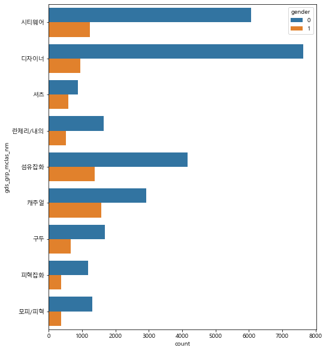

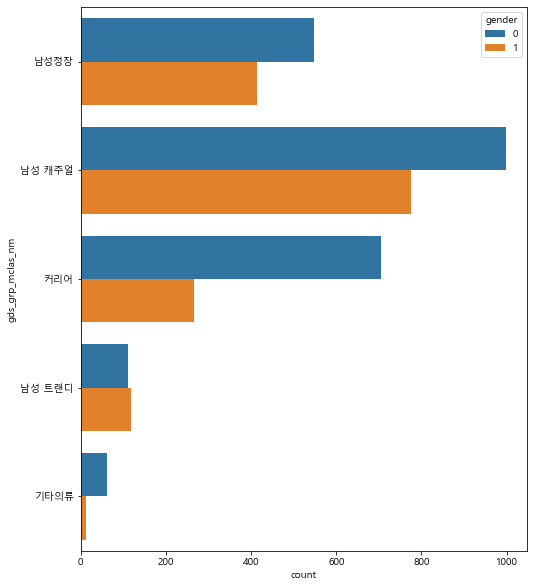

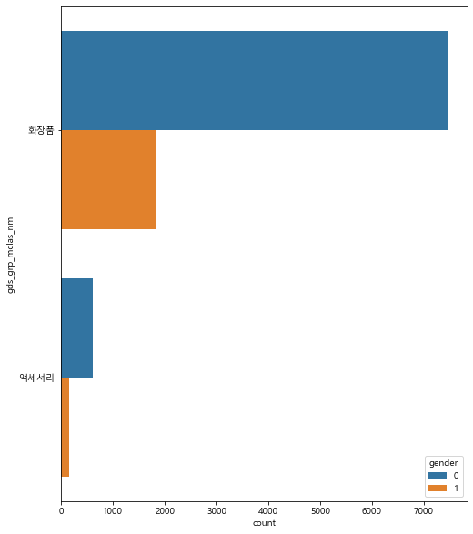

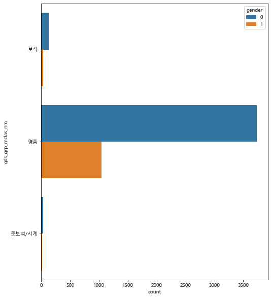

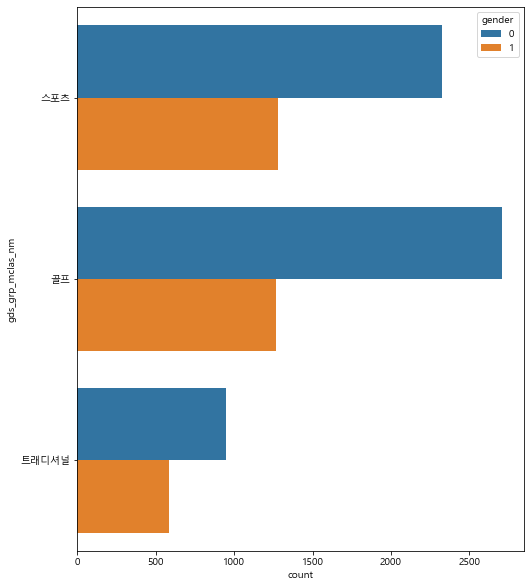

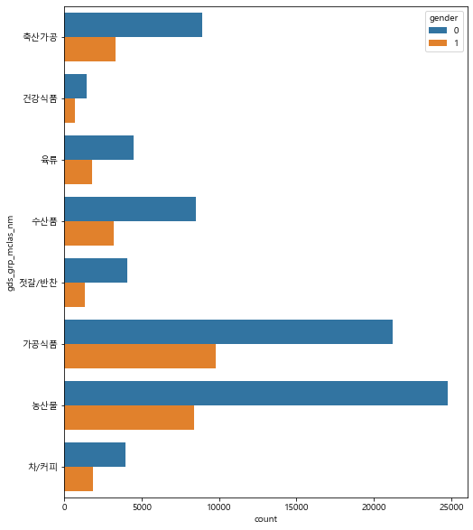

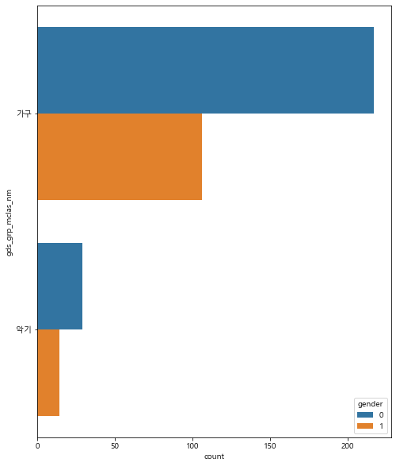

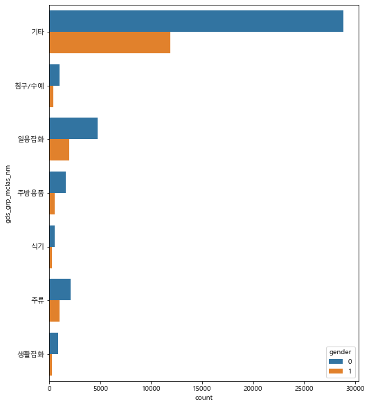

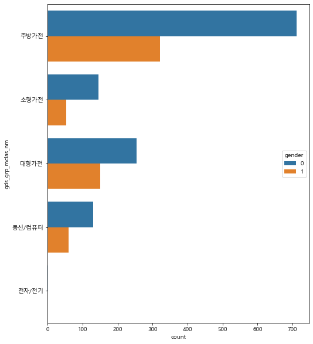

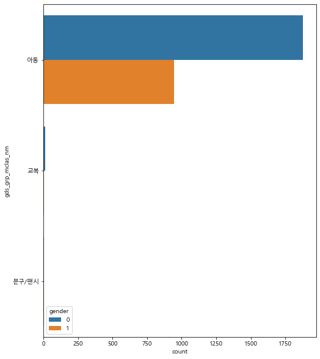

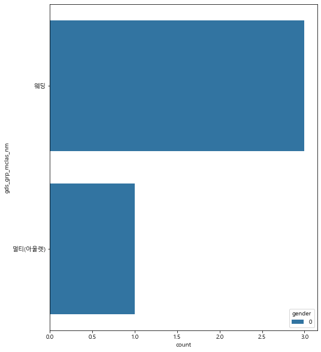

```python
plt.rcParams['figure.figsize'] = [8, 10] # [width, height] (inches)
for mclas in all_mclas:

    display(sns.countplot(data=tr.query(f'gds_grp_mclas_nm in {mclas}'), y='gds_grp_mclas_nm', hue='gender'))
    plt.show()
```

### 2. countplot 으로 상품중분류명 grp_nm 살펴보기

- 상품중분류명을 countplot으로 살펴본 결과 여성보다 남성이 구매수가 더 많은 상품들이 있다
  - 트랜디, 명품남성, 유아용품 이 이에 해당한다
- 명품남성 같은 경우에는 남여 예측에 좋은 구분이 되겠지만, 다른 남성코너에서는 실제로 여성의 구매가 더 많았으므로 이는 남녀를 구분하기에 아직 정보가 부족하다고 생각되어서 상품소분류명까지 보기로 하였다

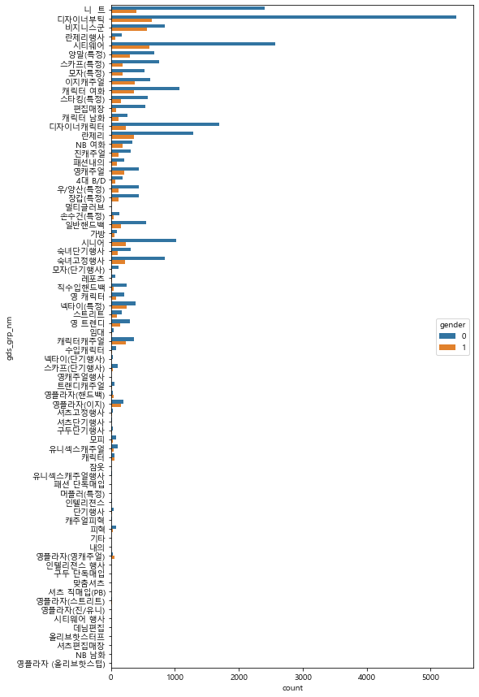

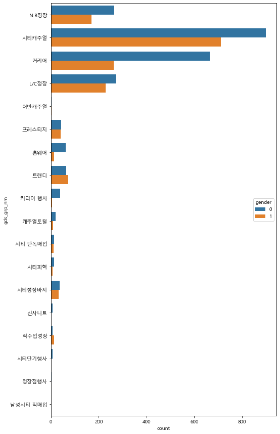

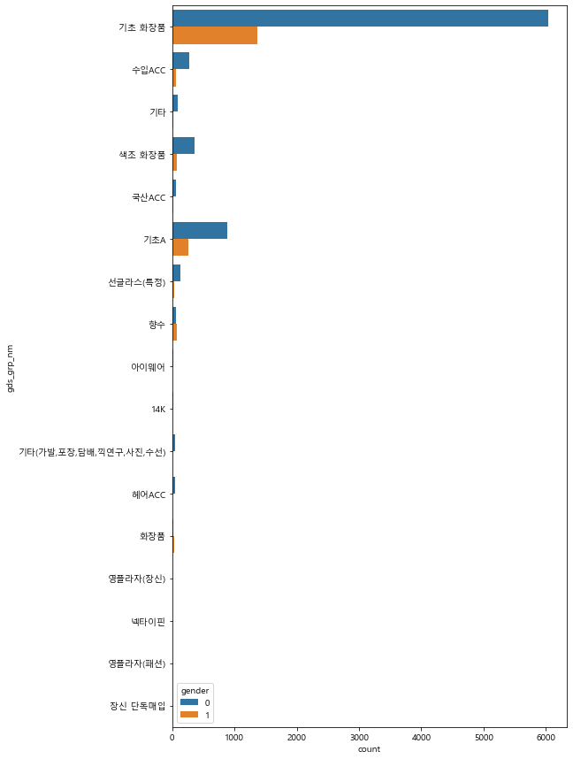

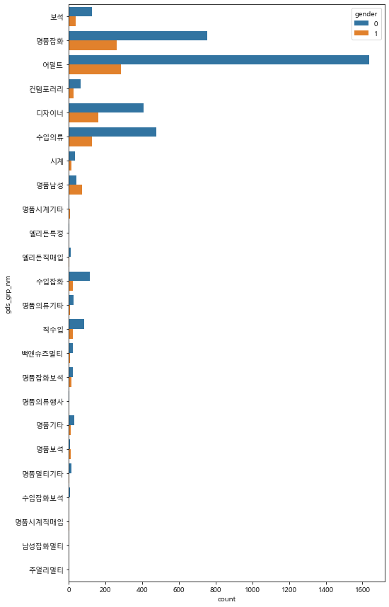

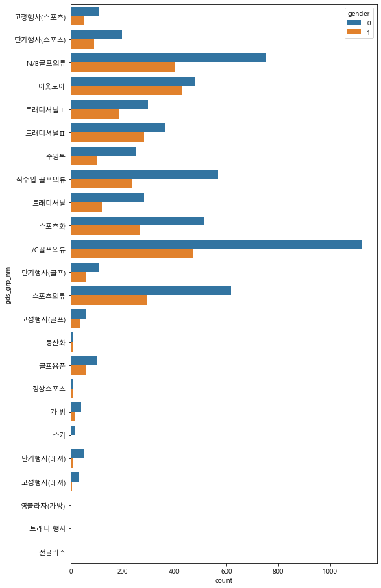

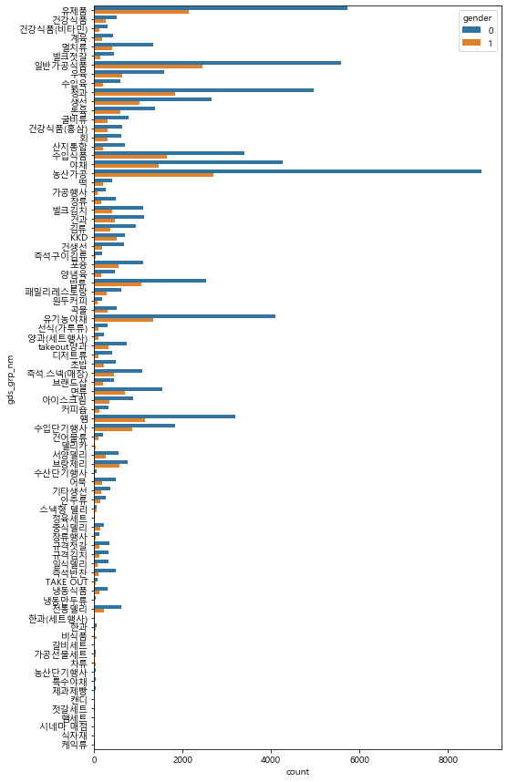

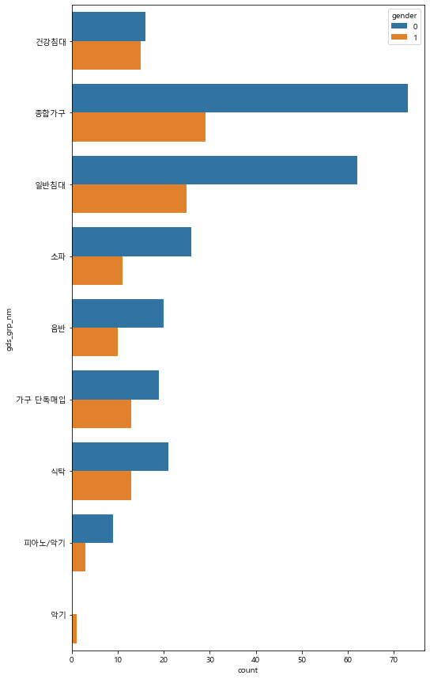

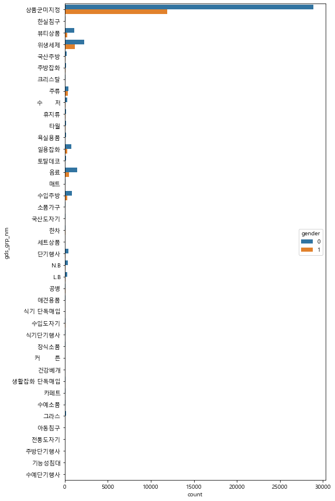

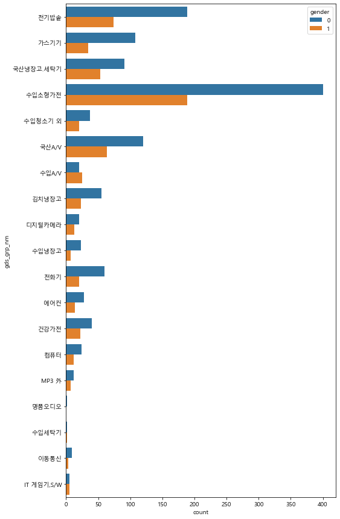

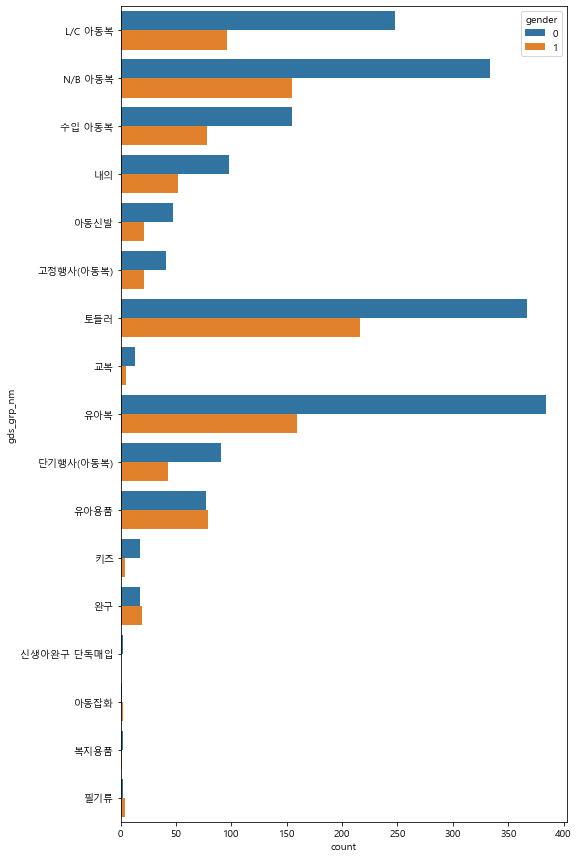

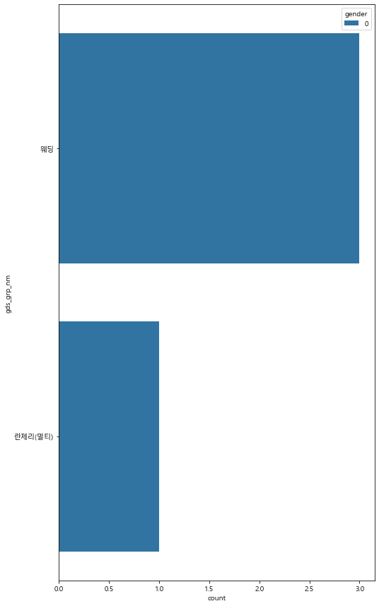

```python
plt.rcParams['figure.figsize'] = [8, 15] # [width, height] (inches)
for mclas in all_mclas:

    display(sns.countplot(data=tr.query(f'gds_grp_mclas_nm in {mclas}'), y='gds_grp_nm', hue='gender'))
    plt.show()
```